# CV_Part2_Face_recognition

• DOMAIN: Entertainment • CONTEXT: Company X owns a movie application and repository which caters movie streaming to millions of users who on subscription basis. Company wants to automate the process of cast and crew information in each scene from a movie such that when a user pauses on the movie and clicks on cast information button, the app will show details of the actor in the scene. Company has an in-house computer vision and multimedia experts who need to detect faces from screen shots from the movie scene. • DATA DESCRIPTION: The dataset comprises of images and its mask where there is a human face. • PROJECT OBJECTIVE: Face detection from training images. Steps and tasks: [ Total Score: 20 points]

```python
# Mounting Google Drive
from google.colab import drive
drive.mount('/content/drive')
```

```python
# Setting the current working directory
import os; os.chdir('drive/My Drive/CV/Face Recognition')
```

```python
# Imports
import pandas as pd, numpy as np, matplotlib.pyplot as plt, sklearn, re, random
import matplotlib.gridspec as gridspec
from tqdm.notebook import tqdm
import tensorflow, cv2
%matplotlib inline

# Extract content from zipfile
from zipfile import ZipFile

# Model
from tensorflow.keras.layers import ZeroPadding2D, Convolution2D, MaxPooling2D, Dropout, Flatten, Activation
from tensorflow.keras.models import Sequential, Model
from sklearn.svm import SVC

# Encode, standardize and PCA
from sklearn.metrics import classification_report, confusion_matrix, accuracy_score
from sklearn.model_selection import RandomizedSearchCV, GridSearchCV
from sklearn.preprocessing import LabelEncoder, StandardScaler
from sklearn.decomposition import PCA

# Set random_state
random_state = 2020

# Suppress warnings, if any
import warnings; warnings.filterwarnings('ignore')

# Print versions
print(f'Pandas version: {pd.__version__}')
print(f'Numpy version: {np.__version__}')
print(f'Scikit-learn version: {sklearn.__version__}')
print(f'Tensorflow version: {tensorflow.__version__}')
print(f'CV version: {cv2.__version__}')
```

```
Pandas version: 1.1.5
Numpy version: 1.19.5
Scikit-learn version: 0.22.2.post1
Tensorflow version: 2.5.0
CV version: 4.1.2
```

```python
!ls
```

```
'Image 2A.jpg'	'Part 3 - Aligned Face Dataset from Pinterest.zip'   pins
'Image 2.jpg'	'Part 3 - vgg_face_weights.h5'			     PINS
```

```python
with ZipFile('Part 3 - Aligned Face Dataset from Pinterest.zip', 'r') as zip:
  zip.extractall()
```

Function to load images Define a function to load the images from the extracted folder and map each image with person id

```python
class IdentityMetadata():
    def __init__(self, base, name, file):
        # print(base, name, file)
        # dataset base directory
        self.base = base
        # identity name
        self.name = name
        # image file name
        self.file = file

    def __repr__(self):
        return self.image_path()

    def image_path(self):
        return os.path.join(self.base, self.name, self.file)

def load_metadata(path):
    metadata = []
    exts = []
    for i in os.listdir(path):
        for f in os.listdir(os.path.join(path, i)):
            # Check file extension. Allow only jpg/jpeg' files.
            ext = os.path.splitext(f)[1]
            if ext == '.jpg' or ext == '.jpeg':
                metadata.append(IdentityMetadata(path, i, f))
                exts.append(ext)
    return np.array(metadata), exts

metadata, exts = load_metadata('PINS')
labels = np.array([meta.name for meta in metadata])
```

```python
def load_image(path):
    img = cv2.imread(path, 1)
    # OpenCV loads images with color channels
    # in BGR order. So we need to reverse them
    return img[...,::-1]
```

```python
n = np.random.randint(1, len(metadata))
img_path = metadata[n].image_path()
img = load_image(img_path)
```

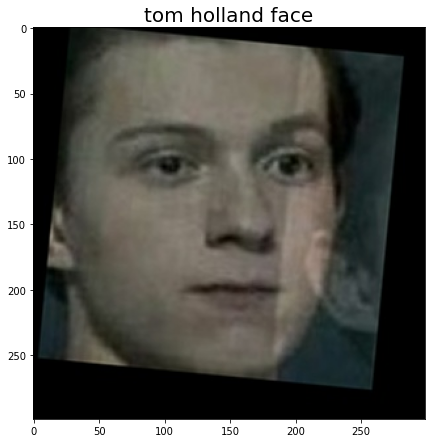

```python
fig = plt.figure(figsize = (15, 7.2))
ax = fig.add_subplot(1, 1, 1)
title = labels[n].split('_')[1]
ax.set_title(title, fontsize = 20)
_ = plt.imshow(img)
```

```python
def vgg_face():
    model = Sequential()
    model.add(ZeroPadding2D((1, 1), input_shape = (224, 224, 3)))
    model.add(Convolution2D(64, (3, 3), activation = 'relu'))
    model.add(ZeroPadding2D((1, 1)))
    model.add(Convolution2D(64, (3, 3), activation = 'relu'))
    model.add(MaxPooling2D((2, 2), strides = (2, 2)))

    model.add(ZeroPadding2D((1, 1)))
    model.add(Convolution2D(128, (3, 3), activation = 'relu'))
    model.add(ZeroPadding2D((1, 1)))
    model.add(Convolution2D(128, (3, 3), activation = 'relu'))
    model.add(MaxPooling2D((2, 2), strides = (2, 2)))

    model.add(ZeroPadding2D((1, 1)))
    model.add(Convolution2D(256, (3, 3), activation = 'relu'))
    model.add(ZeroPadding2D((1, 1)))
    model.add(Convolution2D(256, (3, 3), activation = 'relu'))
    model.add(ZeroPadding2D((1, 1)))
    model.add(Convolution2D(256, (3, 3), activation = 'relu'))
    model.add(MaxPooling2D((2, 2), strides = (2, 2)))

    model.add(ZeroPadding2D((1, 1)))
    model.add(Convolution2D(512, (3, 3), activation = 'relu'))
    model.add(ZeroPadding2D((1, 1)))
    model.add(Convolution2D(512, (3, 3), activation = 'relu'))
    model.add(ZeroPadding2D((1, 1)))
    model.add(Convolution2D(512, (3, 3), activation = 'relu'))
    model.add(MaxPooling2D((2, 2), strides =(2, 2)))

    model.add(ZeroPadding2D((1, 1)))
    model.add(Convolution2D(512, (3, 3), activation = 'relu'))
    model.add(ZeroPadding2D((1, 1)))
    model.add(Convolution2D(512, (3, 3), activation = 'relu'))
    model.add(ZeroPadding2D((1, 1)))
    model.add(Convolution2D(512, (3, 3), activation = 'relu'))
    model.add(MaxPooling2D((2, 2), strides=(2, 2)))

    model.add(Convolution2D(4096, (7, 7), activation = 'relu'))
    model.add(Dropout(0.5))
    model.add(Convolution2D(4096, (1, 1), activation = 'relu'))
    model.add(Dropout(0.5))
    model.add(Convolution2D(2622, (1, 1)))
    model.add(Flatten())
    model.add(Activation('softmax'))
    return model
```

```python
model = vgg_face()
model.load_weights('Part 3 - vgg_face_weights.h5')
print(model.summary())
```

```
Model: "sequential_1"
_________________________________________________________________
Layer (type)                 Output Shape              Param #
=================================================================
zero_padding2d_13 (ZeroPaddi (None, 226, 226, 3)       0
_________________________________________________________________
conv2d_16 (Conv2D)           (None, 224, 224, 64)      1792
_________________________________________________________________
zero_padding2d_14 (ZeroPaddi (None, 226, 226, 64)      0
_________________________________________________________________
conv2d_17 (Conv2D)           (None, 224, 224, 64)      36928
_________________________________________________________________
max_pooling2d_5 (MaxPooling2 (None, 112, 112, 64)      0
_________________________________________________________________
zero_padding2d_15 (ZeroPaddi (None, 114, 114, 64)      0
_________________________________________________________________
conv2d_18 (Conv2D)           (None, 112, 112, 128)     73856
_________________________________________________________________
zero_padding2d_16 (ZeroPaddi (None, 114, 114, 128)     0
_________________________________________________________________
conv2d_19 (Conv2D)           (None, 112, 112, 128)     147584
_________________________________________________________________
max_pooling2d_6 (MaxPooling2 (None, 56, 56, 128)       0
_________________________________________________________________
zero_padding2d_17 (ZeroPaddi (None, 58, 58, 128)       0
_________________________________________________________________
conv2d_20 (Conv2D)           (None, 56, 56, 256)       295168
_________________________________________________________________
zero_padding2d_18 (ZeroPaddi (None, 58, 58, 256)       0
_________________________________________________________________
conv2d_21 (Conv2D)           (None, 56, 56, 256)       590080
_________________________________________________________________
zero_padding2d_19 (ZeroPaddi (None, 58, 58, 256)       0
_________________________________________________________________
conv2d_22 (Conv2D)           (None, 56, 56, 256)       590080
_________________________________________________________________
max_pooling2d_7 (MaxPooling2 (None, 28, 28, 256)       0
_________________________________________________________________
zero_padding2d_20 (ZeroPaddi (None, 30, 30, 256)       0
_________________________________________________________________
```

[output cut: 30 more lines]

```
conv2d_30 (Conv2D)           (None, 1, 1, 4096)        16781312
_________________________________________________________________
dropout_3 (Dropout)          (None, 1, 1, 4096)        0
_________________________________________________________________
conv2d_31 (Conv2D)           (None, 1, 1, 2622)        10742334
_________________________________________________________________
flatten_1 (Flatten)          (None, 2622)              0
_________________________________________________________________
activation_1 (Activation)    (None, 2622)              0
=================================================================
Total params: 145,002,878
Trainable params: 145,002,878
Non-trainable params: 0
_________________________________________________________________
None
```

```python
vgg_face_descriptor = Model(inputs = model.layers[0].input, outputs = model.layers[-2].output)
```

```python
# Get embedding vector for first image in the metadata using the pre-trained model

img_path = metadata[0].image_path()
img = load_image(img_path)

# Normalising pixel values from [0-255] to [0-1]: scale RGB values to interval [0, 1]
img = (img / 255.).astype(np.float32)

img = cv2.resize(img, dsize = (224, 224))
print(img.shape)

# Obtain embedding vector for an image
# Get the embedding vector for the above image using vgg_face_descriptor model and print the shape
embedding_vector = vgg_face_descriptor.predict(np.expand_dims(img, axis = 0))[0]
print(embedding_vector.shape)
```

```
(224, 224, 3)
(2622,)
```

```python
embeddings = []
embeddings = np.zeros((metadata.shape[0], 2622))
for i, meta in tqdm(enumerate(metadata)):
  try:
    image = load_image(str(meta))
    image = (image/255.).astype(np.float32)
    image = cv2.resize(image, (224, 224))
    embeddings[i] = vgg_face_descriptor.predict(np.expand_dims(image, axis = 0))[0]
  except:
    embeddings[i] = np.zeros(2622)
```

```python
def distance(emb1, emb2):
    return np.sum(np.square(emb1 - emb2))
```

```python
def show_pair(idx1, idx2):
    plt.figure(figsize = (8, 3))
    plt.suptitle(f'Distance = {distance(embeddings[idx1], embeddings[idx2]):.2f}')
    plt.subplot(121)
    plt.imshow(load_image(metadata[idx1].image_path()))
    plt.subplot(122)
    plt.imshow(load_image(metadata[idx2].image_path()))
```

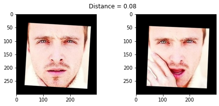

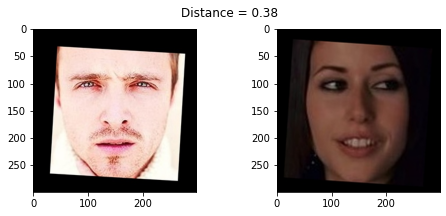

```python
show_pair(2, 3)
show_pair(2, 180)
```

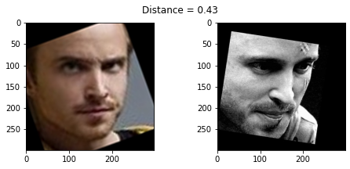

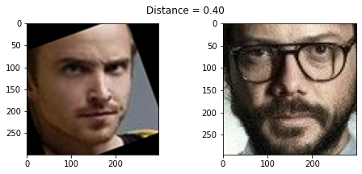

```python
show_pair(30, 31)
show_pair(30, 100)
```

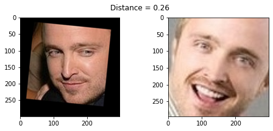

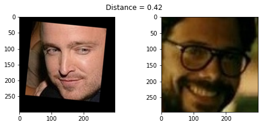

```python
show_pair(70, 72)
show_pair(70, 115)
```

```python
train_idx = np.arange(metadata.shape[0]) % 9 != 0
test_idx = np.arange(metadata.shape[0]) % 9 == 0

# Features
X_train = np.array(embeddings)[train_idx]
X_test = np.array(embeddings)[test_idx]

# Labels
y_train = np.array([meta.name for meta in metadata[train_idx]])
y_test = np.array([meta.name for meta in metadata[test_idx]])

display(X_train.shape, X_test.shape, y_train.shape, y_test.shape)
```

```
(9573, 2622)
```

```
(1197, 2622)
```

```
(9573,)
```

```
(1197,)
```

```python
# Encode labels
en = LabelEncoder()
y_train = en.fit_transform(y_train)
y_test = en.transform(y_test)
```

```python
# Standarize features
sc = StandardScaler()
X_train_sc = sc.fit_transform(X_train)
X_test_sc = sc.transform(X_test)
```

```python
# Covariance matrix
cov_matrix = np.cov(X_train_sc.T)

# Eigen values and vector
eig_vals, eig_vecs = np.linalg.eig(cov_matrix)

# Cumulative variance explained
tot = sum(eig_vals)
var_exp = [(i /tot) * 100 for i in sorted(eig_vals, reverse = True)]
cum_var_exp = np.cumsum(var_exp)

print('Cumulative Variance Explained', cum_var_exp)
```

```
Cumulative Variance Explained [ 13.5782862   18.96284336  22.96169962 ...  99.99999982  99.99999999
 100.        ]
```

```python
# Get index where cumulative variance explained is > threshold
thres = 95
res = list(filter(lambda i: i > thres, cum_var_exp))[0]
index = (cum_var_exp.tolist().index(res))
print(f'Index of element just greater than {thres}: {str(index)}')
```

```
Index of element just greater than 95: 346
```

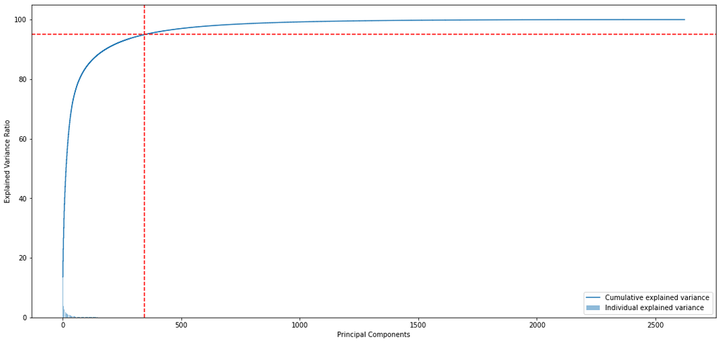

```python
# Ploting
plt.figure(figsize = (15 , 7.2))
plt.bar(range(1, eig_vals.size + 1), var_exp, alpha = 0.5, align = 'center', label = 'Individual explained variance')
plt.step(range(1, eig_vals.size + 1), cum_var_exp, where = 'mid', label = 'Cumulative explained variance')
plt.axhline(y = thres, color = 'r', linestyle = '--')
plt.axvline(x = index, color = 'r', linestyle = '--')
plt.ylabel('Explained Variance Ratio')
plt.xlabel('Principal Components')
plt.legend(loc = 'best')
plt.tight_layout()
plt.show()
```

```python
# Reducing the dimensions
pca = PCA(n_components = index, random_state = random_state, svd_solver = 'full', whiten = True)
pca.fit(X_train_sc)
X_train_pca = pca.transform(X_train_sc)
X_test_pca = pca.transform(X_test_sc)
display(X_train_pca.shape, X_test_pca.shape)
```

```
(9573, 346)
```

```
(1197, 346)
```

```python
svc_pca = SVC(C = 1, gamma = 0.001, kernel = 'rbf', class_weight = 'balanced', random_state = random_state)
svc_pca.fit(X_train_pca, y_train)
print('SVC accuracy for train set: {0:.3f}'.format(svc_pca.score(X_train_pca, y_train)))
```

```
SVC accuracy for train set: 0.995
```

```python
# Predict
y_pred = svc_pca.predict(X_test_pca)

# Accuracy Score
print('Accuracy Score: {}'.format(accuracy_score(y_test, y_pred).round(3)))
```

```
Accuracy Score: 0.962
```

```python
names = [name.split('_')[1].title().strip() for name in labels]

# Classification Report
print('Classification Report: \n{}'.format(classification_report(y_test, y_pred, target_names = np.unique(names))))
```

```
Classification Report:
                          precision    recall  f1-score   support

              Aaron Paul       1.00      1.00      1.00        10
      Alexandra Daddario       0.91      1.00      0.95        10
            Alvaro Morte       1.00      1.00      1.00        13
Alycia Debnam Carey Face       1.00      0.92      0.96        13
             Amanda Crew       1.00      1.00      1.00         7
          Amaury Nolasco       1.00      1.00      1.00         9
        Amber Heard Face       1.00      0.88      0.93         8
               Anna Gunn       0.88      1.00      0.93        14
           Anne Hathaway       1.00      1.00      1.00        14
     Barbara Palvin Face       1.00      0.89      0.94         9
      Bellamy Blake Face       0.93      1.00      0.96        13
    Benedict Cumberbatch       0.93      1.00      0.96        13
            Betsy Brandt       1.00      1.00      1.00         9
              Bill Gates       0.91      1.00      0.95        10
        Brenton Thwaites       1.00      1.00      1.00        16
             Brie Larson       1.00      1.00      1.00        14
            Brit Marling       1.00      0.92      0.96        13
          Bryan Cranston       0.93      1.00      0.97        14
              Caity Lotz       1.00      1.00      1.00        12
        Cameron Monaghan       1.00      1.00      1.00        14
   Chadwick Boseman Face       0.89      0.94      0.91        17
          Chance Perdomo       0.89      1.00      0.94         8
             Chris Evans       1.00      0.79      0.88        14
             Chris Pratt       1.00      1.00      1.00        14
          Cobie Smulders       1.00      0.93      0.97        15
      Danielle Panabaker       1.00      1.00      1.00        14
             Dave Franco       0.93      1.00      0.97        14
            David Mazouz       1.00      1.00      1.00        10
         Dominic Purcell       1.00      1.00      1.00        12
                   Drake       1.00      0.86      0.92         7
           Dua Lipa Face       1.00      1.00      1.00        11
          Dwayne Johnson       1.00      1.00      1.00        12
            Eliza Taylor       1.00      0.92      0.96        13
    Elizabeth Olsen Face       1.00      1.00      1.00        10
               Elon Musk       1.00      0.94      0.97        16
           Emilia Clarke       0.93      1.00      0.96        13
     Emily Bett Rickards       1.00      0.60      0.75         5
```

[output cut: 52 more lines]

```
           Sundar Pichai       0.90      1.00      0.95         9
          Tati Gabrielle       1.00      1.00      1.00         9
            Taylor Swift       1.00      1.00      1.00        14
      Thomas Middleditch       0.92      0.92      0.92        12
            Tom Cavanagh       1.00      1.00      1.00         9
        Tom Holland Face       0.80      0.80      0.80        10
          Ursula Corbero       1.00      0.83      0.91         6
        Wentworth Miller       1.00      1.00      1.00         7
           Willa Holland       0.85      1.00      0.92        11
        William Fichtner       0.92      0.92      0.92        13
                 Zendaya       0.92      1.00      0.96        12

                accuracy                           0.96      1197
               macro avg       0.97      0.96      0.96      1197
            weighted avg       0.97      0.96      0.96      1197
```

```python
def sample_img_plot(sample_idx):
  # Load image for sample_idx from test data
  sample_img = load_image(metadata[test_idx][sample_idx].image_path())
  # Get actual name
  actual_name = metadata[test_idx][sample_idx].name.split('_')[-1].title().strip()
  # Normalizing pixel values
  sample_img = (sample_img/255.).astype(np.float32)
  # Resize
  sample_img = cv2.resize(sample_img, (224, 224))

  # Obtain embedding vector for sample image
  embedding = vgg_face_descriptor.predict(np.expand_dims(sample_img, axis = 0))[0]
  # Scaled the vector and reshape
  embedding_scaled = sc.transform(embedding.reshape(1, -1))
  # Predict
  sample_pred = svc_pca.predict(pca.transform(embedding_scaled))
  # Transform back
  pred_name = en.inverse_transform(sample_pred)[0].split('_')[-1].title().strip()
  return sample_img, actual_name, pred_name
```

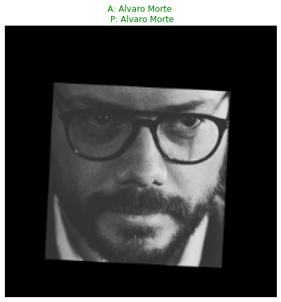

```python
# Plot for 10th image in test data
sample_img, actual_name, pred_name = sample_img_plot(10)
fig = plt.figure(figsize = (15, 7.2))
plt.axis('off')
plt.imshow(sample_img)
plt.title(f"A: {actual_name} \n P: {pred_name}", color = 'green' if actual_name == pred_name else 'red')
plt.show()
```

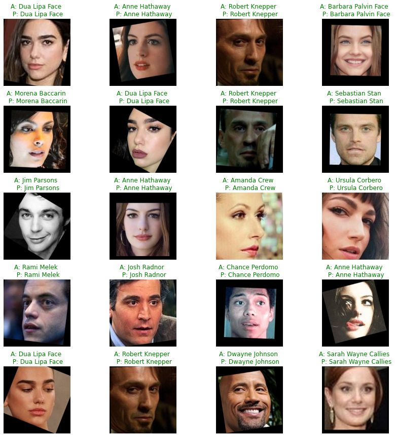

```python
# Random 20 sample images from test data
plt.figure(figsize = (15, 15))
gs1 = gridspec.GridSpec(5, 4)
gs1.update(wspace = 0, hspace = 0.3)

for i in range(20):
    ax1 = plt.subplot(gs1[i])
    plt.axis('on')
    ax1.set_xticklabels([])
    ax1.set_yticklabels([])
    ax1.set_aspect('equal')

    sample_img, actual_name, pred_name = sample_img_plot(random.randint(1, 1197))

    plt.axis('off')
    plt.imshow(sample_img)

    plt.title(f"A: {actual_name} \n P: {pred_name}", color = 'green' if actual_name == pred_name else 'red')
plt.show()
```

```python
sample_img = load_image("Image 2.jpg")
  # Get actual name
actual_name = metadata[test_idx][sample_idx].name.split('_')[-1].title().strip()
  # Normalizing pixel values
sample_img = (sample_img/255.).astype(np.float32)
  # Resize
sample_img = cv2.resize(sample_img, (224, 224))

  # Obtain embedding vector for sample image
embedding = vgg_face_descriptor.predict(np.expand_dims(sample_img, axis = 0))[0]
  # Scaled the vector and reshape
embedding_scaled = sc.transform(embedding.reshape(1, -1))
  # Predict
sample_pred = svc_pca.predict(pca.transform(embedding_scaled))
  # Transform back
pred_name = en.inverse_transform(sample_pred)[0].split('_')[-1].title().strip()
```

[output not shown]